# 聚源数据对比：期货公司持仓排名

William Fang

2017-07-13

## 数据介绍

聚源数据位于 `MySQL` 数据库：`jydb.Fut_MemberRankByContract`。以下介绍各个字段，以及与我们的数据库 `china_futures_bar.oiRank` 相对应的关系：

我已经在提取 `MySQL` 数据库的时候把字段设置为一样

| fieldsJY | fieldsJYName | fieldsOiRank |
| --- | --- | --- |
| ID | 聚源编号 |  |
| EndDate | 交易日期 | TradingDay |
| ExchangeCode | 交易所代码 |  |
| ContractInnerCode | 聚源合约编码 |  |
| ContractCode | 合约代码 | InstrumentID |
| ReportPeriod | 报告期 |  |
| RankNumber | 排名 | Rank |
| MemberInnerCode | 聚源期货公司编码 |  |
| MemberCode | 期货公司代码 |  |
| MemberAbbr | 期货公司名称 | BrokerID |
| IndicatorCode | 变量编码 |  |
| IndicatorName | 变量名称 | ClassID |
| IndicatorVolume | 变量数值 | Amount |
| ChangeVolume | 变动大小 | DiffAmount |
| UpdateTime | 数据库更新时间 |  |
| JSID | 聚源代码 |  |

## 从数据库提取数据

从两个数据表里提取我们需要的数据。目前，聚源的数据最早是到 `2016-06-06`。

如果在提取中文字段的时候，会出现乱码无法显示，这时候需要进行转码处理。使用命令 `iconv(myString, from = 'GB18030', to = 'utf-8')`。

```r
## =============================================================================
## 从数据库读取 jydb 数据
mysql <- mysqlFetch('jydb')
dtJydb <- dbGetQuery(mysql,"
            SELECT EndDate as TradingDay,
                   ContractCode as InstrumentID,
                   RankNumber as Rank,
                   MemberAbbr as BrokerID,
                   IndicatorName as ClassID,
                   IndicatorVolume as Amount,
                   ChangeVolume as DiffAmount
            FROM Fut_MemberRankByContract;
") %>% as.data.table()
dtJydb[, ":="(
    TradingDay = substr(TradingDay,1,10),
    InstrumentID = toupper(InstrumentID),    ## 聚源的是全部大写
    BrokerID = iconv(BrokerID, from = 'GB18030', to = 'utf-8'),
    ClassID  = iconv(ClassID, from = 'GB18030', to = 'utf-8')
    )]
```

```
##          TradingDay InstrumentID Rank   BrokerID      ClassID Amount DiffAmount
##       1: 2016-06-06       AG1606    1   申万期货   成交量统计   1758       1258
##       2: 2016-06-06       AG1606    1   银河期货 持买仓量统计   7654        -34
##       3: 2016-06-06       AG1606    1   永安期货 持卖仓量统计  12782         44
##       4: 2016-06-06       AG1606   10   迈科期货   成交量统计    454        452
##       5: 2016-06-06       AG1606   10   通惠期货 持买仓量统计   1454          0
##      ---
## 5087415: 2017-07-12        M1801  137 黑龙江时代 持买仓量统计     12          0
## 5087416: 2017-07-12        M1801  130 黑龙江时代 持卖仓量统计     23          1
## 5087417: 2017-07-12        M1805  125 黑龙江时代 持买仓量统计      1          0
## 5087418: 2017-07-12        P1801  140 黑龙江时代 持买仓量统计      8          0
## 5087419: 2017-07-12       BU1712   19   瑞奇期货 持买仓量统计    655        239
```

```r
dtJydb[ClassID == '成交量统计', ClassID := 'Turnover'] %>%
  .[ClassID == '持买仓量统计', ClassID := 'longPos'] %>%
  .[ClassID == '持卖仓量统计', ClassID := 'shortPos']
```

```
##          TradingDay InstrumentID Rank   BrokerID  ClassID Amount DiffAmount
##       1: 2016-06-06       AG1606    1   申万期货 Turnover   1758       1258
##       2: 2016-06-06       AG1606    1   银河期货  longPos   7654        -34
##       3: 2016-06-06       AG1606    1   永安期货 shortPos  12782         44
##       4: 2016-06-06       AG1606   10   迈科期货 Turnover    454        452
##       5: 2016-06-06       AG1606   10   通惠期货  longPos   1454          0
##      ---
## 5087415: 2017-07-12        M1801  137 黑龙江时代  longPos     12          0
## 5087416: 2017-07-12        M1801  130 黑龙江时代 shortPos     23          1
## 5087417: 2017-07-12        M1805  125 黑龙江时代  longPos      1          0
## 5087418: 2017-07-12        P1801  140 黑龙江时代  longPos      8          0
## 5087419: 2017-07-12       BU1712   19   瑞奇期货  longPos    655        239
```

```r
## =============================================================================
```

```r
## =============================================================================
## 从数据库读取 oiRank
mysql <- mysqlFetch('china_futures_bar')
dtOiRank <- dbGetQuery(mysql,paste("
            SELECT *
            FROM oiRank
            WHERE TradingDay between", dtJydb[,gsub('-','',min(TradingDay))],
            "AND ", dtJydb[,gsub('-','',max(TradingDay))])
) %>% as.data.table()
dtOiRank[,":="(
    InstrumentID = toupper(InstrumentID),    ## 聚源的是全部大写
    BrokerID = iconv(BrokerID, from = 'GB18030', to = 'utf-8')
)]
```

```
##          TradingDay InstrumentID Rank   BrokerID  ClassID Amount DiffAmount
##       1: 2016-06-06        A1607    1   南华期货  longPos     12         -3
##       2: 2016-06-06        A1607    1   南华期货 Turnover      7          7
##       3: 2016-06-06        A1607    1   大有期货 shortPos     19          0
##       4: 2016-06-06        A1607    2   招商期货 shortPos      2          0
##       5: 2016-06-06        A1607    2 美尔雅期货 Turnover      5          5
##      ---
## 5082838: 2017-07-12       ZN1711   19   宏源期货  longPos    131         23
## 5082839: 2017-07-12       ZN1711   19   永安期货 Turnover    234        124
## 5082840: 2017-07-12       ZN1711   20   东兴期货 shortPos    100         20
## 5082841: 2017-07-12       ZN1711   20   云晨期货 Turnover    201        199
## 5082842: 2017-07-12       ZN1711   20   瑞达期货  longPos    129       -134
```

```r
## =============================================================================
```

## 数据对比

从数据的长度来看，两个数据库的数据基本是一样的。

```r
## 聚源数据
nrow(dtJydb)
```

```
## [1] 5087419
```

```r
## 爬虫数据
nrow(dtOiRank)
```

```
## [1] 5082842
```

下面我做其他方面的对比。

### 合并数据

使用字段来合并两个数据：`by = c('TradingDay', 'InstrumentID', 'ClassID', 'Rank')`。这样，我们就可以对比

- 相同交易日期:`TradingDay`
- 同一只合约:`InstrumentID`
- 同一种类型:`ClassID`
- 在同一个排名:`Rank`

之间的差异。

我试图使用同一个 `BrokerID`，但是系统会报错，好像是做笛卡尔集的时候超过了内存。

```r
dt <- merge(dtJydb, dtOiRank,
    by = c('TradingDay', 'InstrumentID', 'ClassID', 'Rank'), all = TRUE)
dt
```

```
##          TradingDay InstrumentID  ClassID Rank BrokerID.x Amount.x DiffAmount.x
##       1: 2016-06-06        A1607 Turnover    1   南华期货        7            7
##       2: 2016-06-06        A1607 Turnover    2 美尔雅期货        5            5
##       3: 2016-06-06        A1607 Turnover    3   上海大陆        2            1
##       4: 2016-06-06        A1607 Turnover    4   中辉期货        2            2
##       5: 2016-06-06        A1607 Turnover    5   鲁证期货        1            1
##      ---
## 5087510: 2017-07-12       ZN1711 shortPos   16   兴业期货      200            0
## 5087511: 2017-07-12       ZN1711 shortPos   17   国泰君安      132          -37
## 5087512: 2017-07-12       ZN1711 shortPos   18   中信建投      128          -18
## 5087513: 2017-07-12       ZN1711 shortPos   19   南华期货      104           -5
## 5087514: 2017-07-12       ZN1711 shortPos   20   东兴期货      100           20
##          BrokerID.y Amount.y DiffAmount.y
##       1:   南华期货        7            7
##       2: 美尔雅期货        5            5
##       3:   上海大陆        2            1
##       4:   中辉期货        2            2
##       5:   鲁证期货        1            1
##      ---
## 5087510:   兴业期货      200            0
## 5087511:   国泰君安      132          -37
## 5087512:   中信建投      128          -18
## 5087513:   南华期货      104           -5
## 5087514:   东兴期货      100           20
```

### 计算误差 `err`

通过以上的转换与合并，我们能够处理二者之间的差异。

```r
suppressMessages({
dt[, ":="(
    errAmount = Amount.x - Amount.y,
    errDiffAmount = DiffAmount.x - DiffAmount.y
)]

## 如果 BrokerID 不一致，记做 1
dt[, errBrokerID := ifelse(BrokerID.x != BrokerID.y, 1, 0)]
})
```

```
##          TradingDay InstrumentID  ClassID Rank BrokerID.x Amount.x DiffAmount.x
##       1: 2016-06-06        A1607 Turnover    1   南华期货        7            7
##       2: 2016-06-06        A1607 Turnover    2 美尔雅期货        5            5
##       3: 2016-06-06        A1607 Turnover    3   上海大陆        2            1
##       4: 2016-06-06        A1607 Turnover    4   中辉期货        2            2
##       5: 2016-06-06        A1607 Turnover    5   鲁证期货        1            1
##      ---
## 5087510: 2017-07-12       ZN1711 shortPos   16   兴业期货      200            0
## 5087511: 2017-07-12       ZN1711 shortPos   17   国泰君安      132          -37
## 5087512: 2017-07-12       ZN1711 shortPos   18   中信建投      128          -18
## 5087513: 2017-07-12       ZN1711 shortPos   19   南华期货      104           -5
## 5087514: 2017-07-12       ZN1711 shortPos   20   东兴期货      100           20
##          BrokerID.y Amount.y DiffAmount.y errAmount errDiffAmount errBrokerID
##       1:   南华期货        7            7         0             0           0
##       2: 美尔雅期货        5            5         0             0           0
##       3:   上海大陆        2            1         0             0           0
##       4:   中辉期货        2            2         0             0           0
##       5:   鲁证期货        1            1         0             0           0
##      ---
## 5087510:   兴业期货      200            0         0             0           0
## 5087511:   国泰君安      132          -37         0             0           0
## 5087512:   中信建投      128          -18         0             0           0
## 5087513:   南华期货      104           -5         0             0           0
## 5087514:   东兴期货      100           20         0             0           0
```

```r
dt[, summary(errAmount)]
```

```
##    Min. 1st Qu.  Median    Mean 3rd Qu.    Max.    NA's
##       0       0       0       0       0       0    4767
```

```r
dt[, summary(errDiffAmount)]
```

```
##    Min. 1st Qu.  Median    Mean 3rd Qu.    Max.    NA's
##   -4055       0       0       0       0    4055    4767
```

发现，针对 `Amout`, 两个数据库是一致的。但是呢，我也发现这个 `DiffAmount` 是不一样滴。这个有点奇怪。更加奇怪的事情，这个 `effDiffAmount` 竟然是 **对称** 的。有木有！！！

因此，可以推断的是，这里面一定存在某种系统性的偏差。

继续做进一步分析。来看看这个不一样的 errDiffAmount 都是哪些日期，涉及到哪些合约。

```r
dt[errDiffAmount != 0][,unique(TradingDay)]
```

```
##  [1] "2017-01-03" "2017-01-04" "2017-01-05" "2017-01-06" "2017-01-10"
##  [6] "2017-01-11" "2017-01-16" "2017-01-17" "2017-01-18" "2017-01-19"
## [11] "2017-02-03" "2017-03-20" "2017-03-21" "2017-03-22" "2017-03-23"
## [16] "2017-03-24" "2017-03-27" "2017-03-28" "2017-03-29" "2017-03-30"
## [21] "2017-03-31"
```

```r
dt[errDiffAmount != 0][,unique(InstrumentID)]
```

```
##  [1] "C1701"  "C1703"  "C1705"  "C1707"  "C1709"  "C1711"  "CS1705" "I1701"
##  [9] "I1702"  "I1705"  "I1706"  "I1709"  "I1712"  "J1701"  "J1705"  "J1709"
## [17] "JD1701" "JD1702" "JD1703" "JD1705" "JD1708" "JD1709" "JM1701" "JM1705"
## [25] "JM1709" "L1701"  "L1705"  "L1709"  "M1701"  "M1705"  "M1707"  "M1709"
## [33] "P1701"  "P1705"  "P1709"  "PP1701" "PP1705" "PP1709" "V1705"  "V1709"
## [41] "Y1701"  "Y1705"  "Y1709"  "A1705"  "A1709"  "A1801"  "A1805"  "I1704"
## [49] "M1708"  "M1711"  "A1703"  "CS1709" "JM1702" "P1706"  "FB1702" "I1711"
## [57] "JM1703" "V1701"  "I1710"  "JD1704" "JD1706" "JD1707" "CS1703" "I1703"
## [65] "I1708"  "J1702"  "JD1710" "BB1703" "C1801"  "CS1801" "I1801"  "J1801"
## [73] "JD1801" "JM1801" "L1801"  "M1801"  "P1801"  "PP1801" "Y1801"  "FB1709"
## [81] "M1703"  "C1803"  "CS1711" "I1802"  "J1710"  "J1711"  "JD1802" "V1801"
## [89] "I1707"  "CS1707" "A1707"  "I1803"  "JM1707" "J1803"  "JM1710" "JD1803"
## [97] "M1712"
```

惊天大发现！所有的不一致都是发生在这些天，这些合约。因此，我们可以抽一两个数据，跟交易所网站的数据做一个对比，就可以发现问题所在了。

### 与交易所网页对比

我们先拿来 2017-01-03 来看看。

```r
dt[TradingDay == '2017-01-03'][InstrumentID == 'C1701'][errBrokerID == 1]
```

```
##     TradingDay InstrumentID  ClassID Rank BrokerID.x Amount.x DiffAmount.x
##  1: 2017-01-03        C1701 Turnover   12 江苏新纪元        9            2
##  2: 2017-01-03        C1701 Turnover   13   申银万国        9         -367
##  3: 2017-01-03        C1701 Turnover   15   中信建投        5         -429
##  4: 2017-01-03        C1701 Turnover   16   中钢期货        5         -196
##  5: 2017-01-03        C1701 Turnover   17   招商期货        2         -207
##  6: 2017-01-03        C1701 Turnover   18   华信万达        2         -395
##  7: 2017-01-03        C1701 Turnover   20   宏源期货        2          -95
##  8: 2017-01-03        C1701  longPos    6   国都期货        0          -13
##  9: 2017-01-03        C1701  longPos    7   宏源期货        0           -2
## 10: 2017-01-03        C1701  longPos    8   东海期货        0          -42
## 11: 2017-01-03        C1701  longPos    9   中信建投        0           -4
## 12: 2017-01-03        C1701  longPos   10   兴证期货        0          -10
## 13: 2017-01-03        C1701  longPos   11   国金期货        0           -7
## 14: 2017-01-03        C1701  longPos   12   中钢期货        0           -5
```

[output cut: 31 more lines]

机智如我者，已经发现问题了：

- `BrokerID` 出现的错误是，上下位置调换了。而且都是间隔的。
- 更重要的事情是，这两个不一致的 `BrokerID`, 其实 `Amount` 是一样的。这就有点意思，因为我们在做排序的时候，有可能是 **对同样数值的变量，排序方法的不同会导致排名的不同**。

好了，我们去看看交易所的网站。

从上面的合约我们可以看出，基本上，出现不一致的合约都是在 `DCE` 交易的合约。

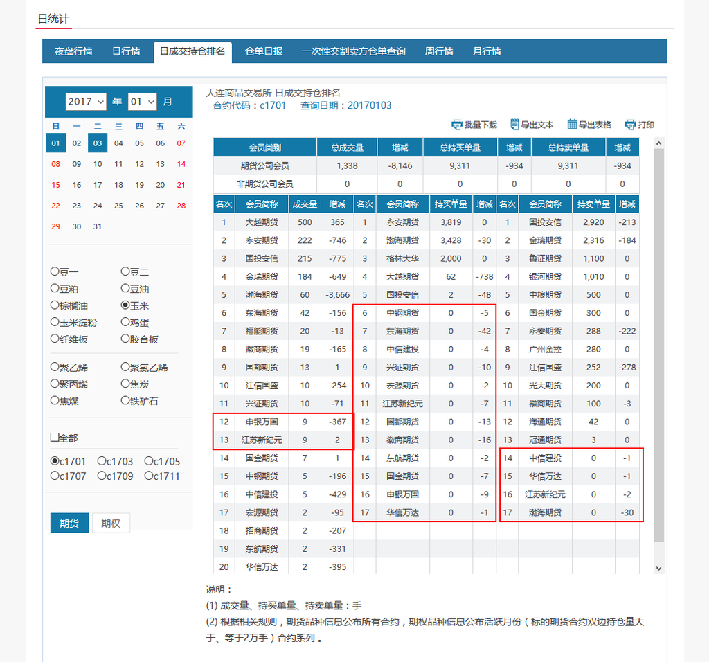

看到没，在这种情况下，**聚源的排名是跟交易所网页不一样的，而我们爬虫的数据是跟交易所一致。**

下面再看看其他的合约

```r
dtJydb[TradingDay == '2017-01-03'][InstrumentID == 'C1703'][ClassID == 'Turnover'][order(Rank)]
```

```
##     TradingDay InstrumentID Rank   BrokerID  ClassID Amount DiffAmount
##  1: 2017-01-03        C1703    1   中粮期货 Turnover    642        641
##  2: 2017-01-03        C1703    2   国金期货 Turnover     70         70
##  3: 2017-01-03        C1703    3   浙商期货 Turnover     38         33
##  4: 2017-01-03        C1703    4   长江期货 Turnover     27          7
##  5: 2017-01-03        C1703    5   方正中期 Turnover     16         13
##  6: 2017-01-03        C1703    6   广发期货 Turnover     15         -1
##  7: 2017-01-03        C1703    7   中航期货 Turnover     15         15
##  8: 2017-01-03        C1703    8   海通期货 Turnover     13         -2
##  9: 2017-01-03        C1703    9   永安期货 Turnover     13         -4
## 10: 2017-01-03        C1703   10   五矿经易 Turnover     13        -50
## 11: 2017-01-03        C1703   11   国投安信 Turnover     12          9
## 12: 2017-01-03        C1703   12   新湖期货 Turnover     12         -7
## 13: 2017-01-03        C1703   13   平安期货 Turnover     12        -13
## 14: 2017-01-03        C1703   14   华泰期货 Turnover     11          5
```

[output cut: 37 more lines]

```r
dtOiRank[TradingDay == '2017-01-03'][InstrumentID == 'C1703'][ClassID == 'Turnover'][order(Rank)]
```

```
##     TradingDay InstrumentID Rank   BrokerID  ClassID Amount DiffAmount
##  1: 2017-01-03        C1703    1   中粮期货 Turnover    642        641
##  2: 2017-01-03        C1703    2   国金期货 Turnover     70         70
##  3: 2017-01-03        C1703    3   浙商期货 Turnover     38         33
##  4: 2017-01-03        C1703    4   长江期货 Turnover     27          7
##  5: 2017-01-03        C1703    5   方正中期 Turnover     16         13
##  6: 2017-01-03        C1703    6   中航期货 Turnover     15         15
##  7: 2017-01-03        C1703    7   广发期货 Turnover     15         -1
##  8: 2017-01-03        C1703    8   海通期货 Turnover     13         -2
##  9: 2017-01-03        C1703    9   永安期货 Turnover     13         -4
## 10: 2017-01-03        C1703   10   五矿经易 Turnover     13        -50
## 11: 2017-01-03        C1703   11   新湖期货 Turnover     12         -7
## 12: 2017-01-03        C1703   12   国投安信 Turnover     12          9
## 13: 2017-01-03        C1703   13   平安期货 Turnover     12        -13
## 14: 2017-01-03        C1703   14   华泰期货 Turnover     11          5
```

[output cut: 37 more lines]

```r
dt[TradingDay == '2017-01-03'][InstrumentID == 'C1703'][ClassID == 'Turnover'][errBrokerID ==1]
```

```
##     TradingDay InstrumentID  ClassID Rank BrokerID.x Amount.x DiffAmount.x
##  1: 2017-01-03        C1703 Turnover    6   广发期货       15           -1
##  2: 2017-01-03        C1703 Turnover    7   中航期货       15           15
##  3: 2017-01-03        C1703 Turnover   11   国投安信       12            9
##  4: 2017-01-03        C1703 Turnover   12   新湖期货       12           -7
##  5: 2017-01-03        C1703 Turnover   19   国海良时        5          -26
##  6: 2017-01-03        C1703 Turnover   20   国泰君安        5           -6
##  7: 2017-01-03        C1703 Turnover   21   华信万达        4            4
##  8: 2017-01-03        C1703 Turnover   23   福能期货        4            2
##  9: 2017-01-03        C1703 Turnover   24   中原期货        4            4
## 10: 2017-01-03        C1703 Turnover   41   山西三立        1            1
## 11: 2017-01-03        C1703 Turnover   42 江苏新纪元        1           -1
## 12: 2017-01-03        C1703 Turnover   44   汇鑫期货        1            1
## 13: 2017-01-03        C1703 Turnover   46   河北恒银        1            0
## 14: 2017-01-03        C1703 Turnover   47   大连良运        1            0
##     BrokerID.y Amount.y DiffAmount.y errAmount errDiffAmount errBrokerID
##  1:   中航期货       15           15         0           -16           1
##  2:   广发期货       15           -1         0            16           1
##  3:   新湖期货       12           -7         0            16           1
##  4:   国投安信       12            9         0           -16           1
##  5:   国泰君安        5           -6         0           -20           1
##  6:   国海良时        5          -26         0            20           1
##  7:   中原期货        4            4         0             0           1
##  8:   华信万达        4            4         0            -2           1
##  9:   福能期货        4            2         0             2           1
## 10:   汇鑫期货        1            1         0             0           1
## 11:   山西三立        1            1         0            -2           1
## 12:   河北恒银        1            0         0             1           1
## 13:   大连良运        1            0         0             0           1
## 14: 江苏新纪元        1           -1         0             1           1
```

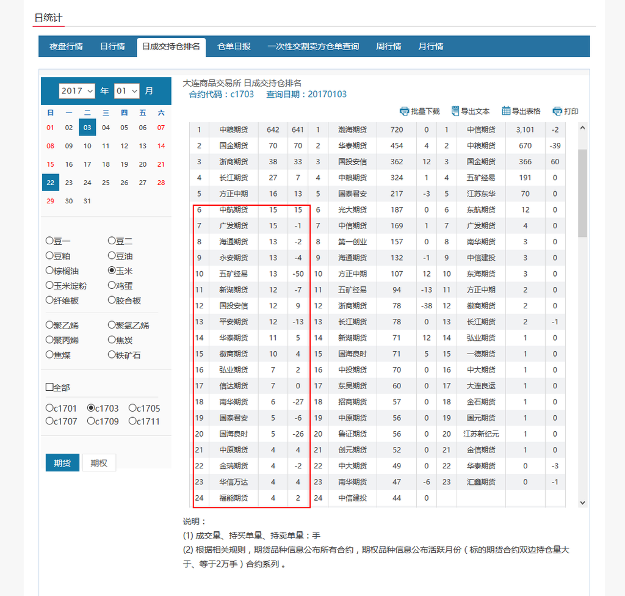

哦科，现在比较明朗了。

再换一个交易日期，比如，2017-03-31.

```r
dtJydb[TradingDay == '2017-03-31'][InstrumentID == 'A1705'][ClassID == 'longPos'][order(Rank)]
```

```
##      TradingDay InstrumentID Rank BrokerID ClassID Amount DiffAmount
##   1: 2017-03-31        A1705    1 格林大华 longPos   3429        277
##   2: 2017-03-31        A1705    2 银河期货 longPos   2186       -136
##   3: 2017-03-31        A1705    3 永安期货 longPos   1983       -143
##   4: 2017-03-31        A1705    4 国投安信 longPos   1854        -47
##   5: 2017-03-31        A1705    5 南华期货 longPos   1736         31
##  ---
## 140: 2017-03-31        A1705  140 华闻期货 longPos      3         -4
## 141: 2017-03-31        A1705  141 山金期货 longPos      3         -1
## 142: 2017-03-31        A1705  142 通惠期货 longPos      3          0
## 143: 2017-03-31        A1705  143 天富期货 longPos      2          0
## 144: 2017-03-31        A1705  144 上海浙石 longPos      1          0
```

```r
dtOiRank[TradingDay == '2017-03-31'][InstrumentID == 'A1705'][ClassID == 'longPos'][order(Rank)]
```

```
##      TradingDay InstrumentID Rank BrokerID ClassID Amount DiffAmount
##   1: 2017-03-31        A1705    1 格林大华 longPos   3429        277
##   2: 2017-03-31        A1705    2 银河期货 longPos   2186       -136
##   3: 2017-03-31        A1705    3 永安期货 longPos   1983       -143
##   4: 2017-03-31        A1705    4 国投安信 longPos   1854        -47
##   5: 2017-03-31        A1705    5 南华期货 longPos   1736         31
##  ---
## 140: 2017-03-31        A1705  140 通惠期货 longPos      3          0
## 141: 2017-03-31        A1705  141 山金期货 longPos      3         -1
## 142: 2017-03-31        A1705  142 华闻期货 longPos      3         -4
## 143: 2017-03-31        A1705  143 天富期货 longPos      2          0
## 144: 2017-03-31        A1705  144 上海浙石 longPos      1          0
```

```r
dt[TradingDay == '2017-03-31'][InstrumentID == 'A1705'][ClassID == 'longPos'][errBrokerID ==1]
```

```
##     TradingDay InstrumentID ClassID Rank BrokerID.x Amount.x DiffAmount.x
##  1: 2017-03-31        A1705 longPos   68   冠通期货      187          -13
##  2: 2017-03-31        A1705 longPos   69   招金期货      187           -7
##  3: 2017-03-31        A1705 longPos   80   中州期货      107          -19
##  4: 2017-03-31        A1705 longPos   81   金信期货      107          -16
##  5: 2017-03-31        A1705 longPos   82   英大期货      104          -34
##  6: 2017-03-31        A1705 longPos   83   神华期货      104           -3
##  7: 2017-03-31        A1705 longPos   87   国金期货       96           -6
##  8: 2017-03-31        A1705 longPos   88 新纪元期货       96           -1
##  9: 2017-03-31        A1705 longPos  101   迈科期货       66            1
## 10: 2017-03-31        A1705 longPos  102   深圳瑞龙       66            3
## 11: 2017-03-31        A1705 longPos  103   江西瑞奇       58            8
## 12: 2017-03-31        A1705 longPos  104   先融期货       58          -22
## 13: 2017-03-31        A1705 longPos  118   华西期货       22          -18
## 14: 2017-03-31        A1705 longPos  119   海证期货       22          -38
```

[output cut: 39 more lines]

```r
dtJydb[TradingDay == '2017-03-31'][InstrumentID == 'A1705'][ClassID == 'longPos'][order(Rank)][Rank %between% c(60,70)]
```

```
##     TradingDay InstrumentID Rank BrokerID ClassID Amount DiffAmount
##  1: 2017-03-31        A1705   60 云晨期货 longPos    212         -2
##  2: 2017-03-31        A1705   61 中航期货 longPos    206        -17
##  3: 2017-03-31        A1705   62 北京首创 longPos    204        -63
##  4: 2017-03-31        A1705   63 兴证期货 longPos    203       -126
##  5: 2017-03-31        A1705   64 东兴期货 longPos    195        -63
##  6: 2017-03-31        A1705   65 德盛期货 longPos    194         91
##  7: 2017-03-31        A1705   66 华联期货 longPos    193        -10
##  8: 2017-03-31        A1705   67 天鸿期货 longPos    189          0
##  9: 2017-03-31        A1705   68 冠通期货 longPos    187        -13
## 10: 2017-03-31        A1705   69 招金期货 longPos    187         -7
## 11: 2017-03-31        A1705   70 金元期货 longPos    179         -7
```

```r
dtOiRank[TradingDay == '2017-03-31'][InstrumentID == 'A1705'][ClassID == 'longPos'][order(Rank)][Rank %between% c(60,70)]
```

```
##     TradingDay InstrumentID Rank BrokerID ClassID Amount DiffAmount
##  1: 2017-03-31        A1705   60 云晨期货 longPos    212         -2
##  2: 2017-03-31        A1705   61 中航期货 longPos    206        -17
##  3: 2017-03-31        A1705   62 北京首创 longPos    204        -63
##  4: 2017-03-31        A1705   63 兴证期货 longPos    203       -126
##  5: 2017-03-31        A1705   64 东兴期货 longPos    195        -63
##  6: 2017-03-31        A1705   65 德盛期货 longPos    194         91
##  7: 2017-03-31        A1705   66 华联期货 longPos    193        -10
##  8: 2017-03-31        A1705   67 天鸿期货 longPos    189          0
##  9: 2017-03-31        A1705   68 招金期货 longPos    187         -7
## 10: 2017-03-31        A1705   69 冠通期货 longPos    187        -13
## 11: 2017-03-31        A1705   70 金元期货 longPos    179         -7
```

```r
dtJydb[TradingDay == '2017-03-31'][InstrumentID == 'A1705'][ClassID == 'longPos'][order(Rank)][Rank %between% c(100,102)]
```

```
##    TradingDay InstrumentID Rank BrokerID ClassID Amount DiffAmount
## 1: 2017-03-31        A1705  100 国富期货 longPos     67        -20
## 2: 2017-03-31        A1705  101 迈科期货 longPos     66          1
## 3: 2017-03-31        A1705  102 深圳瑞龙 longPos     66          3
```

```r
dtOiRank[TradingDay == '2017-03-31'][InstrumentID == 'A1705'][ClassID == 'longPos'][order(Rank)][Rank %between% c(100,102)]
```

```
##    TradingDay InstrumentID Rank BrokerID ClassID Amount DiffAmount
## 1: 2017-03-31        A1705  100 国富期货 longPos     67        -20
## 2: 2017-03-31        A1705  101 深圳瑞龙 longPos     66          3
## 3: 2017-03-31        A1705  102 迈科期货 longPos     66          1
```

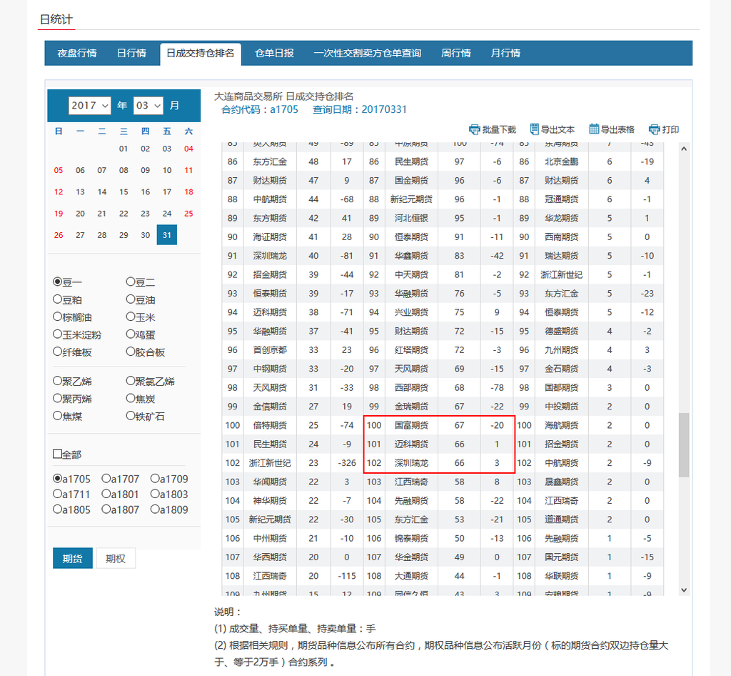

这一次，**聚聚的数据是正确的，而我们的数据是不一致，但是，实际上，二者的数量是一样的，所以从统计的角度看排名，理论上应该赋予同一个数值。**

## 结论

通过以上的对比分析，我们可以得到以下结论：

- 两个数据源在数据的数量上面基本上一致，不存在显著性的差异

  这儿之间的绝对值差别为 4577，相对于 5087419 基本上是没有影响。
- 从 `Amout` 的角度看，这个是一样的，也就是说，**在同一个交易日期，针对同一个合约，Amout 都不存在差异**
- 但是，由于二者采用的排序处理方法的差异，**可能导致同一个数值的 Amout, 会给予不同的排序，这个可以通过我们自己处理来解决**
- 处理方法即：
> 1. 先 group by c(TradingDay, InstrumentID, ClassID)
> 2. 然后在组内使用函数 rank(x, ties.method = ‘min’)， 对同一个数值，使用同样的排名。